# Midterm_21500268, ParkSeongchan

Park Seongchan

2020 4 24

## Loading Library and Data

사용하는 library들을 불러옵니다.

## Part 1

# Q1

```r
head(pums.sample)
```

```
##   PINCP SEX AGEP MAR                              COW
## 1 22900   1   43   1 Employee of a private for-profit
## 2 17800   2   51   1        Local government employee
## 3 56800   1   55   1 Employee of a private for-profit
## 4  6100   2   23   5 Employee of a private for-profit
## 5 12000   2   23   5 Employee of a private for-profit
## 6 26300   2   73   2 Employee of a private for-profit
##                             SCHL WKHP  FER JWMNP           DIS
## 1 some college credit, no degree   40 <NA>     5 no disability
## 2    Regular high school diploma   35 <NA>    40 no disability
## 3 some college credit, no degree   50 <NA>    15  w/disability
## 4  GED or alternative credential   23  yes    28 no disability
## 5 some college credit, no degree   40   no    10 no disability
## 6 some college credit, no degree   40 <NA>    30  w/disability
```

```r
str(pums.sample)
```

```
## 'data.frame':    2672 obs. of  10 variables:
##  $ PINCP: num  22900 17800 56800 6100 12000 26300 7100 16200 31500 14000 ...
##  $ SEX  : num  1 2 1 2 2 2 2 2 1 1 ...
##  $ AGEP : num  43 51 55 23 23 73 49 42 56 42 ...
##  $ MAR  : num  1 1 1 5 5 2 2 5 1 1 ...
##  $ COW  : Factor w/ 7 levels "Employee of a private for-profit",..: 1 3 1 1 1 1 1 1 1 1 ...
##  $ SCHL : Factor w/ 9 levels "no high school diploma",..: 4 2 4 3 4 4 1 2 2 1 ...
##  $ WKHP : num  40 35 50 23 40 40 20 40 40 50 ...
##  $ FER  : Factor w/ 2 levels "no","yes": NA NA NA 2 1 NA 1 1 NA NA ...
##  $ JWMNP: num  5 40 15 28 10 30 50 10 10 60 ...
##  $ DIS  : Factor w/ 2 levels "w/disability",..: 2 2 1 2 2 1 1 2 2 2 ...
```

```r
sapply(pums.sample, class)
```

```
##     PINCP       SEX      AGEP       MAR       COW      SCHL      WKHP       FER
## "numeric" "numeric" "numeric" "numeric"  "factor"  "factor" "numeric"  "factor"
##     JWMNP       DIS
## "numeric"  "factor"
```

2672 obs. of 10 variables 입니다.

그리고 sapply 함수를 통해서 각 변수들의 type을 알 수 있습니다.

1. ‘SEX’ 변수는 남자와 여자를 의미하는 1, 2로 구성되어 있습니다. 이는 각각의 숫자가 의미를 가지고 있는 분류형 이기 때문에 factor 변수형으로 변경해야 합니다.
2. ‘MAR’ 변수는 결혼의 형태를 나타내기 때문에 각각의 숫자들이 의미를 가지고 있습니다. 따라서 factor 변수형으로 변경해야 합니다.

나머지 변수들은 적절한 type으로 설정되어 있습니다.

# Q2

```r
table(pums.sample$SEX)
```

```
##
##    1    2
## 1393 1279
```

```r
pums.sample$SEX <- ifelse(pums.sample$SEX == 1, 'Male', 'Female')
table(pums.sample$SEX)
```

```
##
## Female   Male
##   1279   1393
```

```r
pums.sample$SEX <- as.factor(pums.sample$SEX)
```

먼저 table을 통해 1, 2로 구성되어 있는 것을 확인합니다.

그리고 ifelse 함수를 통해 남자는 1, 여자는 2로 할당해줍니다.

남성, 여성이라는 것은 각각의 의미가 분류형의 의미를 가지고 있기 때문에 factor형 변수로 바꿔줍니다.

# Q3

```r
table(pums.sample$MAR)
```

```
##
##    1    2    3    4    5
## 1492   64  316   53  747
```

```r
pums.sample$MAR <- ifelse(pums.sample$MAR == 1, 'Married',
                          ifelse(pums.sample$MAR == 2, 'Widowed',
                                 ifelse(pums.sample$MAR == 3, 'Divorced',
                                        ifelse(pums.sample$MAR == 4, 'Separated', 'Never married or under 15 years old'))))
table(pums.sample$MAR)
```

```
##
##                            Divorced                             Married
##                                 316                                1492
## Never married or under 15 years old                           Separated
##                                 747                                  53
##                             Widowed
##                                  64
```

```r
pums.sample$MAR <- as.factor(pums.sample$MAR)
```

먼저 table을 통해서 1, 2, 3, 4, 5로 나뉜 것을 확인합니다.

그리고 ifelse 함수를 통해서 각각에 해당하는 값을 할당시킵니다.

앞선 문제와 동일하게 이는 5개로 나뉜 각각의 내용들이 분류형의 의미를 가지고 있기 때문에 factor형 변수로 바꿔줍니다.

# Q4

```r
colSums(is.na(pums.sample))
```

```
## PINCP   SEX  AGEP   MAR   COW  SCHL  WKHP   FER JWMNP   DIS
##     0     0     0     0     6     0     0  1798   119     0
```

```r
colSums(is.na(pums.sample)) / nrow(pums.sample)
```

```
##       PINCP         SEX        AGEP         MAR         COW        SCHL
## 0.000000000 0.000000000 0.000000000 0.000000000 0.002245509 0.000000000
##        WKHP         FER       JWMNP         DIS
## 0.000000000 0.672904192 0.044535928 0.000000000
```

각 변수의 missing value는 colSums 함수를 통해 구할 수 있습니다.

Missing Value가 있는 변수인 ’FER’에서는 0.67290419이고, ’JWMNP’에서는 0.044535928 정도 전체에 비해 NA가 존재한다고 할 수 있습니다.

# Q5

```r
table(is.na(pums.sample$FER))
```

```
##
## FALSE  TRUE
##   874  1798
```

```r
table(pums.sample$FER)
```

```
##
##  no yes
## 836  38
```

```r
male <- pums.sample %>% filter(SEX == 'Male')
table(male$FER)
```

```
##
##  no yes
##   0   0
```

```r
table(is.na(male$FER))
```

```
##
## TRUE
## 1393
```

```r
female <- pums.sample %>% filter(SEX == 'Female')
young_female <- female %>% filter(AGEP < 15)
old_female <- female %>% filter(AGEP > 50)

table(old_female$FER)
```

```
##
##  no yes
##   0   0
```

```r
table(is.na(old_female$FER))
```

```
##
## TRUE
##  405
```

기존의 pums.sample의 FER 변수에서의 NA의 값을 구하면, 총 1798개가 나온다.

그래서 dplyr 패키지를 통해 남자와 여자인 데이터를 따로 분리하여 각각 male과 female이라는 새로운 데이터를 만든다.

male 데이터에서 is.na를 하게 되면 총 1393개가 나온다.

female 데이터에서는 15세 미만인 집단을 young_female으로, 50세 초과인 집단을 old_female으로 나눴다.

그리고 각각에서 is.na을 하면, young_female에는 데이터가 없었고, old_female에서는 405개가 나왔다.

따라서 남자와 여자의 NA의 합인 1393 + 405는 총 NA의 개수인 1798개가 나온다.

# Q6

```r
summary(pums.sample)
```

```
##      PINCP            SEX            AGEP
##  Min.   : -8700   Female:1279   Min.   :16.00
##  1st Qu.: 16000   Male  :1393   1st Qu.:31.00
##  Median : 32000                 Median :43.00
##  Mean   : 45651                 Mean   :42.65
##  3rd Qu.: 56130                 3rd Qu.:53.00
##  Max.   :570000                 Max.   :84.00
##
##                                   MAR
##  Divorced                           : 316
##  Married                            :1492
##  Never married or under 15 years old: 747
##  Separated                          :  53
##  Widowed                            :  64
##
##
##                                COW                                   SCHL
##  Employee of a private for-profit:1716   some college credit, no degree:662
##  Private not-for-profit employee : 267   Regular high school diploma   :645
##  Local government employee       : 195   Bachelor's degree             :486
##  Self-employed not incorporated  : 187   no high school diploma        :272
##  State government employee       : 126   Associate's degree            :216
##  (Other)                         : 175   Master's degree               :209
##  NA's                            :   6   (Other)                       :182
##       WKHP         FER           JWMNP                  DIS
##  Min.   : 1.00   no  : 836   Min.   :  1.0   w/disability : 178
##  1st Qu.:35.00   yes :  38   1st Qu.: 10.0   no disability:2494
##  Median :40.00   NA's:1798   Median : 20.0
##  Mean   :38.21               Mean   : 25.6
##  3rd Qu.:40.00               3rd Qu.: 30.0
##  Max.   :99.00               Max.   :162.0
##                              NA's   :119
```

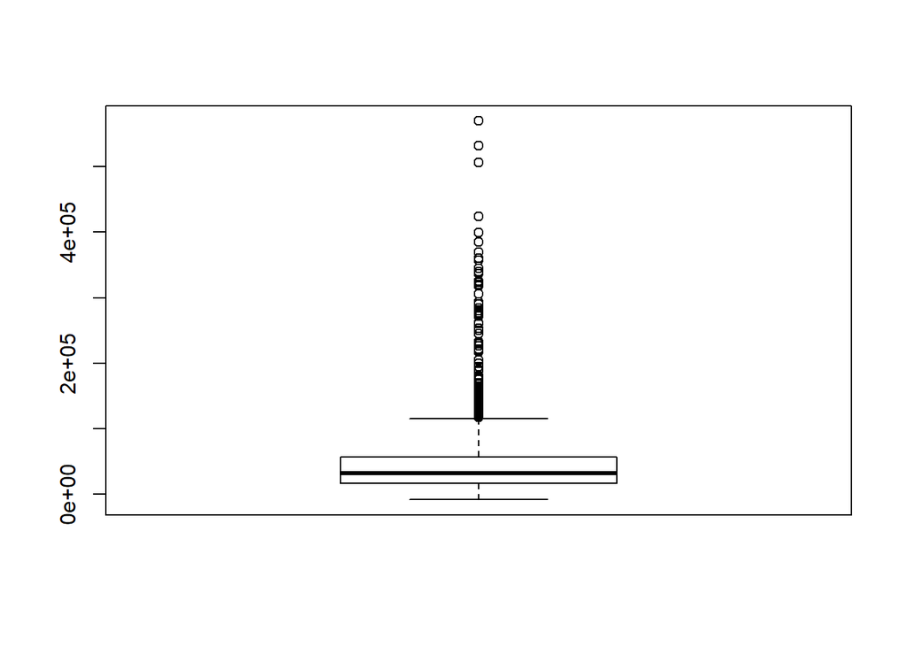

```r
boxplot(pums.sample$PINCP)
```

변수에 outlier가 존재하는지 확인하기 위해 summary 함수를 이용한다.

’PINCP’는 연봉을 의미하는데, 최솟값이 -8700인 것을 볼 수 있다. 이 값이 빚을 의미하는건지 등 정확히 의미하는 바를 몰라서 명백하지는 않겠지만, outlier가 될 수도 있다.

이외의 변수들에서는 outlier을 찾기 어려운 것 같다.

# Q7

```r
aggregate(COW ~ SCHL, pums.sample, table)
```

```
##                             SCHL COW.Employee of a private for-profit
## 1         no high school diploma                                  210
## 2    Regular high school diploma                                  459
## 3  GED or alternative credential                                   55
## 4 some college credit, no degree                                  451
## 5             Associate's degree                                  134
## 6              Bachelor's degree                                  283
## 7                Master's degree                                   88
## 8            Professional degree                                   24
## 9               Doctorate degree                                   12
##   COW.Private not-for-profit employee COW.Local government employee
## 1                                  15                            15
## 2                                  49                            39
## 3                                   8                             6
## 4                                  62                            38
```

[output cut: 25 more lines]

```r
table(pums.sample$COW)
```

```
##
## Employee of a private for-profit  Private not-for-profit employee
##                             1716                              267
##        Local government employee        State government employee
##                              195                              126
##      Federal government employee   Self-employed not incorporated
##                               83                              187
##       Self-employed incorporated
##                               92
```

```r
table(pums.sample$SCHL)
```

```
##
##         no high school diploma    Regular high school diploma
##                            272                            645
##  GED or alternative credential some college credit, no degree
##                             93                            662
##             Associate's degree              Bachelor's degree
##                            216                            486
##                Master's degree            Professional degree
##                            209                             58
##               Doctorate degree
##                             31
```

```r
aggregate(COW == 'Employee of a private for-profit' ~ SCHL, pums.sample, mean)
```

```
##                             SCHL COW == "Employee of a private for-profit"
## 1         no high school diploma                                 0.7720588
## 2    Regular high school diploma                                 0.7127329
## 3  GED or alternative credential                                 0.5913978
## 4 some college credit, no degree                                 0.6843703
## 5             Associate's degree                                 0.6203704
## 6              Bachelor's degree                                 0.5847107
## 7                Master's degree                                 0.4210526
## 8            Professional degree                                 0.4137931
## 9               Doctorate degree                                 0.3870968
```

```r
aggregate(COW == 'Private not-for-profit employee' ~ SCHL, pums.sample, mean)
```

```
##                             SCHL COW == "Private not-for-profit employee"
## 1         no high school diploma                               0.05514706
## 2    Regular high school diploma                               0.07608696
## 3  GED or alternative credential                               0.08602151
## 4 some college credit, no degree                               0.09408194
## 5             Associate's degree                               0.12037037
## 6              Bachelor's degree                               0.11570248
## 7                Master's degree                               0.16267943
## 8            Professional degree                               0.17241379
## 9               Doctorate degree                               0.22580645
```

```r
aggregate(COW == 'Local government employee' ~ SCHL, pums.sample, mean)
```

```
##                             SCHL COW == "Local government employee"
## 1         no high school diploma                         0.05514706
## 2    Regular high school diploma                         0.06055901
## 3  GED or alternative credential                         0.06451613
## 4 some college credit, no degree                         0.05766313
## 5             Associate's degree                         0.05555556
## 6              Bachelor's degree                         0.09090909
## 7                Master's degree                         0.15311005
## 8            Professional degree                         0.12068966
## 9               Doctorate degree                         0.06451613
```

```r
aggregate(COW == 'State government employee' ~ SCHL, pums.sample, mean)
```

```
##                             SCHL COW == "State government employee"
## 1         no high school diploma                         0.01102941
## 2    Regular high school diploma                         0.02329193
## 3  GED or alternative credential                         0.08602151
## 4 some college credit, no degree                         0.04248862
## 5             Associate's degree                         0.06018519
## 6              Bachelor's degree                         0.06404959
## 7                Master's degree                         0.10047847
## 8            Professional degree                         0.00000000
## 9               Doctorate degree                         0.22580645
```

```r
aggregate(COW == 'Federal government employee' ~ SCHL, pums.sample, mean)
```

```
##                             SCHL COW == "Federal government employee"
## 1         no high school diploma                          0.007352941
## 2    Regular high school diploma                          0.017080745
## 3  GED or alternative credential                          0.032258065
## 4 some college credit, no degree                          0.021244310
## 5             Associate's degree                          0.074074074
## 6              Bachelor's degree                          0.045454545
## 7                Master's degree                          0.052631579
## 8            Professional degree                          0.068965517
## 9               Doctorate degree                          0.000000000
```

```r
aggregate(COW == 'Self-employed not incorporated' ~ SCHL, pums.sample, mean)
```

```
##                             SCHL COW == "Self-employed not incorporated"
## 1         no high school diploma                              0.08823529
## 2    Regular high school diploma                              0.06677019
## 3  GED or alternative credential                              0.10752688
## 4 some college credit, no degree                              0.07283763
## 5             Associate's degree                              0.04166667
## 6              Bachelor's degree                              0.06404959
## 7                Master's degree                              0.06220096
## 8            Professional degree                              0.10344828
## 9               Doctorate degree                              0.09677419
```

```r
aggregate(COW == 'Self-employed incorporated' ~ SCHL, pums.sample, mean)
```

```
##                             SCHL COW == "Self-employed incorporated"
## 1         no high school diploma                          0.01102941
## 2    Regular high school diploma                          0.04347826
## 3  GED or alternative credential                          0.03225806
## 4 some college credit, no degree                          0.02731411
## 5             Associate's degree                          0.02777778
## 6              Bachelor's degree                          0.03512397
## 7                Master's degree                          0.04784689
## 8            Professional degree                          0.12068966
## 9               Doctorate degree                          0.00000000
```

aggregate 함수를 통해서 교육수준과 종사업종 사이의 형태들을 알아볼 수 있다.

또한 COW의 값 별로 SCHL의 비율들을 구할 수 있다.

이 결과를 통해 교육수준에 따라서 종사업종이 비슷한 결과이기 보다는 다양한 형태로 분포된 것을 확인할 수 있다.

# Q8

```r
table(pums.sample$AGEP < 20)
```

```
##
## FALSE  TRUE
##  2556   116
```

```r
pums.sample$AGEP_group <- ifelse(pums.sample$AGEP < 30, '20대',
                                 ifelse(pums.sample$AGEP < 40, '30대',
                                        ifelse(pums.sample$AGEP < 50, '40대',
                                               ifelse(pums.sample$AGEP < 60, '50대', '60대 이상'))))
table(pums.sample$AGEP_group)
```

```
##
##      20대      30대      40대      50대 60대 이상
##       602       504       636       583       347
```

```r
aggregate(PINCP ~ AGEP_group, pums.sample, mean)
```

```
##   AGEP_group    PINCP
## 1       20대 21306.69
## 2       30대 48491.21
## 3       40대 51634.66
## 4       50대 55747.96
## 5  60대 이상 55829.38
```

20세 보다 어린 사람이 table 함수를 통해서 확인하니 116명이 있었다. 주어진 조건에 따라서 이들도 모두 20대로 넣었다.

그 후에 aggregate 함수로 나이 그룹별 평균 소득을 구했다.

이를 통해 확인해보니, 가장 소득이 높은 그룹은 ’60대 이상’이었고, 가장 소득이 낮은 그룹은 ’20대’였다.

# Q9

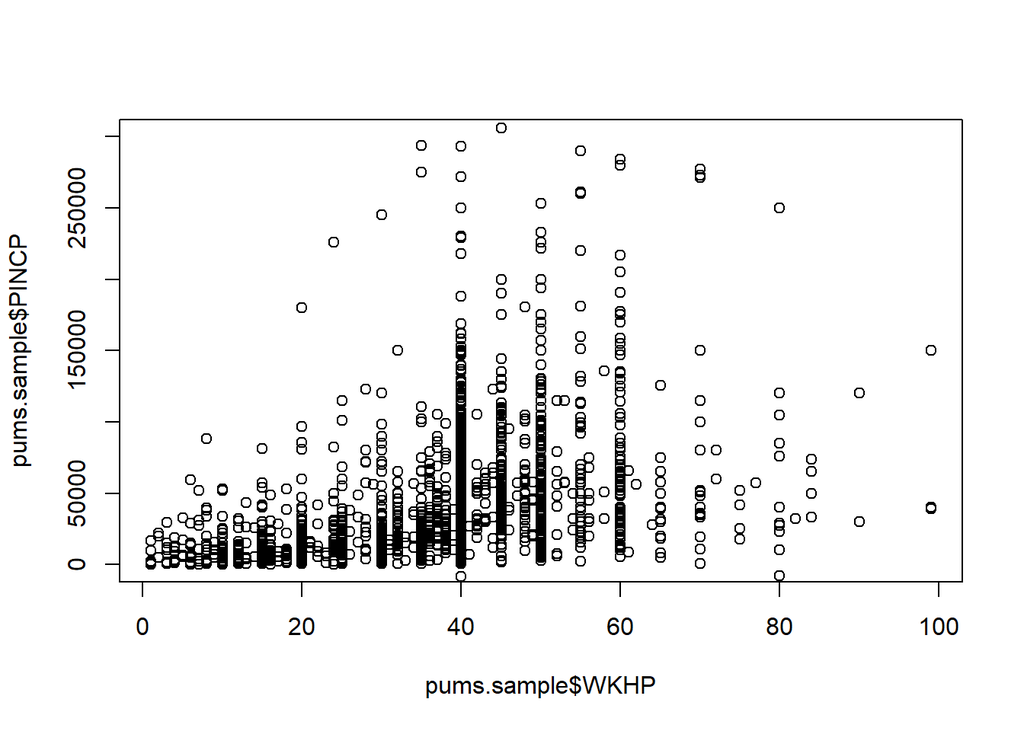

```r
plot(x = pums.sample$WKHP, y = pums.sample$PINCP, ylim = c(0, 300000))
```

```r
aggregate(PINCP ~ WKHP, pums.sample, mean)
```

```
##    WKHP      PINCP
## 1     1   5952.000
## 2     2  15653.333
## 3     3   9971.429
## 4     4   8482.857
## 5     5  13640.000
## 6     6  14451.000
## 7     7  15531.111
## 8     8  15063.158
## 9     9   9425.000
## 10   10  10246.850
## 11   12  11190.519
## 12   13  15766.667
## 13   14  15650.000
## 14   15  12694.545
```

[output cut: 55 more lines]

```r
mean(pums.sample$WKHP)
```

```
## [1] 38.20696
```

```r
aggregate(PINCP ~ WKHP > 38, pums.sample, mean)
```

```
##   WKHP > 38    PINCP
## 1     FALSE 22514.12
## 2      TRUE 56021.96
```

plot 함수를 통해서 x축에는 WKHP를, y축에는 PINCP를 넣어서 표현했다.

이 그래프를 통해서 전반적으로 근무시간이 적을수록 소득을 적게 받고 있는 것을 확인할 수 있었다.

조금더 구체적인 관계를 파악하기 위하여 aggregate 함수를 통해서 WKHP 별로 PINCP의 평균을 구했다.

그리고 이를 객관적으로 비교하기 위하여 WKHP의 평균인 38시간을 기준으로 소득의 평균 값을 비교했다.

그 결과, 근무시간이 평균보다 높았던 사람들이 적었던 사람들보다 훨씬 소득이 높음을 알 수 있다.

# Q10

```r
save(pums.sample, file = 'st21500268.RData')
```

지금까지 작업한 data frame을 주어진 조건에 따라 RData로 저장한다.

## Part 2

# Q1

```r
str(iris)
```

```
## 'data.frame':    150 obs. of  5 variables:
##  $ Sepal.Length: num  5.1 4.9 4.7 4.6 5 5.4 4.6 5 4.4 4.9 ...
##  $ Sepal.Width : num  3.5 3 3.2 3.1 3.6 3.9 3.4 3.4 2.9 3.1 ...
##  $ Petal.Length: num  1.4 1.4 1.3 1.5 1.4 1.7 1.4 1.5 1.4 1.5 ...
##  $ Petal.Width : num  0.2 0.2 0.2 0.2 0.2 0.4 0.3 0.2 0.2 0.1 ...
##  $ Species     : Factor w/ 3 levels "setosa","versicolor",..: 1 1 1 1 1 1 1 1 1 1 ...
```

```r
iris$id <- 1:150

iris.wide <- gather(iris, measure, value, 1:4)
iris.wide <- separate(iris.wide, measure,
                      into = c('Part', 'Measure'),
                      sep = '\\.')

iris.wide <- spread(iris.wide, Measure, value)
iris.wide <- iris.wide[, -2]
head(iris.wide)
```

```
##   Species  Part Length Width
## 1  setosa Petal    1.4   0.2
## 2  setosa Sepal    5.1   3.5
## 3  setosa Petal    1.4   0.2
## 4  setosa Sepal    4.9   3.0
## 5  setosa Petal    1.3   0.2
## 6  setosa Sepal    4.7   3.2
```

```r
str(iris.wide)
```

```
## 'data.frame':    300 obs. of  4 variables:
##  $ Species: Factor w/ 3 levels "setosa","versicolor",..: 1 1 1 1 1 1 1 1 1 1 ...
##  $ Part   : chr  "Petal" "Sepal" "Petal" "Sepal" ...
##  $ Length : num  1.4 5.1 1.4 4.9 1.3 4.7 1.5 4.6 1.4 5 ...
##  $ Width  : num  0.2 3.5 0.2 3 0.2 3.2 0.2 3.1 0.2 3.6 ...
```

str 함수를 통해 iris 데이터의 형태를 파악한다. 총 150개의 observations을 가지고 있다.

이후 작업에서 spread 함수를 써야 하기 때문에 같은 항목끼리 분류해주는 의미로 id 변수를 추가한다.

그리고 gather 함수로 1:4열을 measure과 value로 변환시키고, ’.’을 기준으로 separate 시켜준다.

그 후, spread 함수를 통해서 Measure을 key로, value를 늘려준다.

그리고 처음에 분류를 위해 만들었던 id를 없애고, 다시 iris.wide에 할당시킨다.

최종적으로 다시 str 함수를 통해 확인하면 300개의 observations과 4개의 variables이 조건과 같이 나온 것을 볼 수 있다.

# Q2

```r
iris.tidy <- gather(iris, measure, Value, 1:4)
iris.tidy <- separate(iris.tidy, measure,
                      into = c('Part', 'Measure'),
                      sep = '\\.')

str(iris.tidy)
```

```
## 'data.frame':    600 obs. of  5 variables:
##  $ Species: Factor w/ 3 levels "setosa","versicolor",..: 1 1 1 1 1 1 1 1 1 1 ...
##  $ id     : int  1 2 3 4 5 6 7 8 9 10 ...
##  $ Part   : chr  "Sepal" "Sepal" "Sepal" "Sepal" ...
##  $ Measure: chr  "Length" "Length" "Length" "Length" ...
##  $ Value  : num  5.1 4.9 4.7 4.6 5 5.4 4.6 5 4.4 4.9 ...
```

```r
iris.tidy <- iris.tidy[, -2]
head(iris.tidy)
```

```
##   Species  Part Measure Value
## 1  setosa Sepal  Length   5.1
## 2  setosa Sepal  Length   4.9
## 3  setosa Sepal  Length   4.7
## 4  setosa Sepal  Length   4.6
## 5  setosa Sepal  Length   5.0
## 6  setosa Sepal  Length   5.4
```

```r
save(pums.sample, iris.wide, iris.tidy, file = 'st21500268.RData')
```

먼저 gather을 통해서 iris 데이터의 1:4열을 measure와 value로 변환시킨다.

그리고 measure 값에서 ’.’을 기준으로 앞과 뒤를 separate 시켜준다.

그리고 1, 2번에서 만든 data frame을 주어진 조건에 맞게 RData로 저장한다.